# Prog Assignment

Sathish

February 25, 2017

## Background

Using devices such as Jawbone Up, Nike FuelBand, and Fitbit it is now possible to collect a large amount of data about personal activity relatively inexpensively. These type of devices are part of the quantified self movement - a group of enthusiasts who take measurements about themselves regularly to improve their health, to find patterns in their behavior, or because they are tech geeks. One thing that people regularly do is quantify how much of a particular activity they do, but they rarely quantify how well they do it. In this project, your goal will be to use data from accelerometers on the belt, forearm, arm, and dumbell of 6 participants. They were asked to perform barbell lifts correctly and incorrectly in 5 different ways. More information is available from the website here: http://groupware.les.inf.puc-rio.br/har (see the section on the Weight Lifting Exercise Dataset).

The goal of your project is to predict the manner in which they did the exercise. This is the “classe” variable in the training set. You may use any of the other variables to predict with. You should create a report describing how you built your model, how you used cross validation, what you think the expected out of sample error is, and why you made the choices you did. You will also use your prediction model to predict 20 different test cases.

## Load libraries

```r
suppressMessages(library(plyr)) # sapply
suppressMessages(library(caret)) # Machine Learning
suppressMessages(library(e1071)) # SVM
suppressMessages(library(rpart)) # Partition
suppressMessages(library(rattle)) # fancyRPlot
suppressMessages(library(randomForest)) # Random Forest (faster than caret)
suppressMessages(library(gbm)) # Boosting (faster than caret)
```

## Load data

Load training and test datasets. Note that a number of columns are empty or contain NA values, which will not be used in the model. Also, the first 6 columns do not contain information that are relevant for a predictor.

```r
trainset <- read.csv("pml-training.csv",na.strings=c("","NA"),row.names=1)
testset <- read.csv("pml-testing.csv",na.strings=c("","NA"),row.names=1)

## Remove unnecessary columns (bad data, not relevant data etc.)
trainset <- trainset[,!sapply(trainset,function (x) any(is.na(x)))]
testset <- testset[,!sapply(testset,function (x) any(is.na(x)))]

trainset <- trainset[,-c(1:6)]
testset <- testset[,-c(1:6)]
```

## Reproducibility

Create training, validation and test data sets with reproducible results.

```r
set.seed(19)
inTrain <- createDataPartition(trainset$classe,p=0.7,list=FALSE)
training <- trainset[inTrain,]
validation <- trainset[-inTrain,]
```

## Recursive Partitioning

Try recursive partitioning using all predictors. The accuracy of this method is not very high; the out of sample error is just as good as a random coin toss.

```
##  Accuracy
## 0.4956669
```

[figure not shown]

## Random Forest

Next try Random Forest. It produces high accuracy and the importance plot shows the relevant variables.

```r
fit2 <- randomForest(classe ~ .,data=training,proximity=TRUE)
p2 <- predict(fit2,validation)
cm2 <- confusionMatrix(p2,validation$classe)
print(cm2$overall[1])
```

```
##  Accuracy
## 0.9947324
```

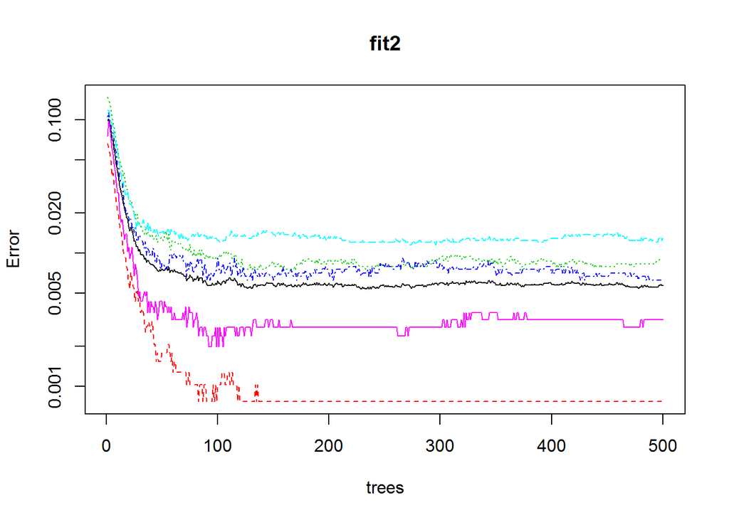

```r
plot(fit2, log="y")
```

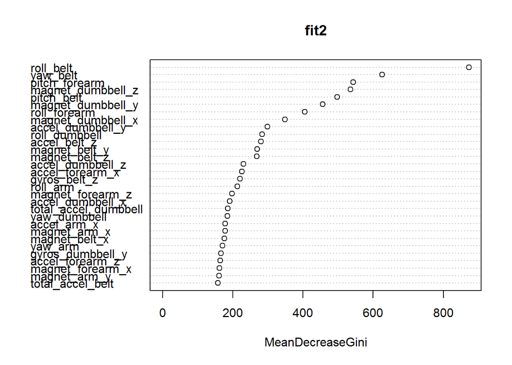

```r
varImpPlot(fit2)
```

## Support Vector Machine

SVM also produces good results but not quite as high as Random Forest.

```r
fit3 <- svm(classe ~ .,data=training)
p3 <- predict(fit3,validation)
cm3 <- confusionMatrix(p3,validation$classe)
print(cm3$overall[1])
```

```
##  Accuracy
## 0.9395072
```

## Linear Discriminant Analysis

Next try LDA but it doesn’t perform nearly as well.

```r
fit4 <- train(classe ~ .,data=training,method="lda")
p4 <- predict(fit4,validation)
cm4 <- confusionMatrix(p4,validation$classe)
print(cm4$overall[1])
```

```
##  Accuracy
## 0.6949873
```

## Predict using test set and Random Forest model

Now predict the test data set using Random Forest method since it performed very well during training phase and had the lowest out of sample error.

```r
p <- predict(fit2,testset)
print(p)
```

```
##  1  2  3  4  5  6  7  8  9 10 11 12 13 14 15 16 17 18 19 20
##  B  A  B  A  A  E  D  B  A  A  B  C  B  A  E  E  A  B  B  B
## Levels: A B C D E
```